# Pruebas de Hipotesis RStudio

Profesora: Helen Guillén Oviedo

2024-05-23

*Pruebas de hipotesis para la media*

*Ejemplo* Con el fin de estudiar el número medio de flexiones continuas que pueden realizar sus alumnos, un profesor de educación física somete a 75 de ellos, elegidos aleatoriamente, a una prueba. El número de flexiones realizado por cada alumno, así como su sexo y si realizan o no deporte fuera del horario escolar se muestran en el fichero *Flexiones.txt.* Lectura de datos

```r
if(!require("readxl")){
install.packages("readxl")
library("readxl")
}
datos<- read_excel("Flexiones.xlsx")
length(datos$Flexiones)
```

```
## [1] 75
```

```r
summary(datos)
```

```
##    Flexiones            Sexo       Deporte
##  Min.   :35.00   Length   :75   Min.   :0.0
##  1st Qu.:48.00   N.unique : 2   1st Qu.:0.0
##  Median :50.00   N.blank  : 0   Median :0.0
##  Mean   :50.11   Min.nchar: 1   Mean   :0.4
##  3rd Qu.:54.00   Max.nchar: 1   3rd Qu.:1.0
##  Max.   :60.00                  Max.   :1.0
```

*Ejemplo 1* Se sabe que el número de flexiones se distribuye según una Normal de varianza poblacional 7.5. ¿Puede asumirse, considerando un nivel de significación del 5%, que el número medio de flexiones que realizan los alumnos es de 55?

solución: 1. mu= número medio de flexiones

2. mu=55 3 Ho:mu=55 H1:mu != 55 *(importante)* “two.sided” (dos colas)

Todas las opciones son “two.sided” (distinto), “less” (menor), “greater” (mayor)

Cargar el paquete *install.packages(“BSDA”)* Luego planteamos las pruebas

```r
if(!require("BSDA")){
install.packages("BSDA")
library("BSDA")
}
z.test(x=datos$Flexiones,y=NULL,alternative="two.sided",mu=55,sigma.x=sqrt(7.5),sigma.y=NULL,conf.level=0.95)
```

```
##
##  One-sample z-Test
##
## data:  datos$Flexiones
## z = -15.474, p-value < 2.2e-16
## alternative hypothesis: true mean is not equal to 55
## 95 percent confidence interval:
##  49.48687 50.72646
## sample estimates:
## mean of x
##  50.10667
```

interpretación: con un nivel de significancia del 5% existe suficiente evidencia estadistica para concluir que el número medio de flexiones que realizan los alumnos es distinta de 55.

*Ejemplo2* Caso2: Desviación estandar poblacional desconocida, muestras grandes.

Suponga para el mismo ejemplo que la varianza poblacional es deconocida.

identificar las hipotesis para tener la hipotesis alterna. 1. mu= número medio de flexiones

2. mu=55 3 Ho:mu=55 H1:mu != 55 *(importante)* “two.sided” (dos colas) Dado que n=75>30 entonces se sigue una distrbucion normal para el estadístico de prueba.

```r
if(!require("BSDA")){
install.packages("BSDA")
library("BSDA")
}
z.test(x=datos$Flexiones,y=NULL,alternative="two.sided",mu=55,
       sigma.x=sd(datos$Flexiones),sigma.y=NULL,conf.level=0.95)
```

```
##
##  One-sample z-Test
##
## data:  datos$Flexiones
## z = -7.088, p-value = 1.36e-12
## alternative hypothesis: true mean is not equal to 55
## 95 percent confidence interval:
##  48.75358 51.45976
## sample estimates:
## mean of x
##  50.10667
```

Interpretación: con un nivel de significancia del 5% existe suficiente evidencia estadistica para concluir que el número medio de flexiones que realizan los alumnos es distinto de 55.

*Ejercicio 1:* Se desea contrastar con un nivel de significancia del 5% la hipótesis de que la estatura media de los hombres de 18 o más años de un país es menor que 175 cm. Suponiendo que la desviación estándar es de 4.5. Para dicha prueba se recolectaron los datos que constituyen una muestra de n=14 hombres seleccionados al azar, cuyas alturas en cm son: 167 167 168 168 168 169 171 172 173 175 175 175 177 182. suponiendo que la poblacion se distribuye de manera normal.

1. mu: estatura media de los hombres de 18 o más años.
2. mu<175
3. H_0:mu>=175 H_1:mu<175

```r
if(!require("BSDA")){
install.packages("BSDA")
library("BSDA")
}
x<-c(167,167,168,168,168,169,171,172,173,175,175,175,177,182)
z.test(x,y=NULL, alternative="less", mu=175,sigma.x=4.5 ,sigma.y=NULL, conf.level=0.95)
```

```
##
##  One-sample z-Test
##
## data:  x
## z = -2.5538, p-value = 0.005327
## alternative hypothesis: true mean is less than 175
## 95 percent confidence interval:
##        NA 173.9068
## sample estimates:
## mean of x
##  171.9286
```

p-valor=0.005327<0.05=alpha se rechaza H0

*Interpretación:* Con un nivel de significancia del 5%, existe suficiente evidencia estadistica para concluir que la estatura media de los hombres de 18 o más años es menor a 175 cm.

*Ejercicio 2:* Cierta cadena de almacenes de descuentos emite su propia tarjeta de credito. La gerente de credito, desea descubrir si el promedio sin pagar mensual es más de $405. El nivel de significancia se fija en 0.01.Para ello se tomo una muestra de 39 datos, los cuales se muestran a continuacion: 395,400,410,415,400,398,403,390,389,391,406,412,403,400,396,410,404,410,420,405,406,418,397,395,408,400,409,419,417,402,405,400,414,399,411,405,412,418,413. ¿Debe la gerente concluir que el promedio sin pagar mensual de la poblacion es mayor a $405?

1. mu: promedio sin pagar mensual en tarjetas de credito
2. mu>405
3. H_o: mu<=405 H_1: mu>405

```r
if(!require("BSDA")){
install.packages("BSDA")
library("BSDA")
}
x<-c(395,400,410,415,400,398,403,390,389,391,406,412,403,400,396,410,404,410,420,405,406,418,397,395,408,400,409,419,417,402,405,400,414,399,411,405,412,418,413)
length(x)
```

```
## [1] 39
```

```r
z.test(x,y=NULL, alternative="greater", mu=405,sigma.x=sd(x) ,sigma.y=NULL)
```

```
##
##  One-sample z-Test
##
## data:  x
## z = 0.19243, p-value = 0.4237
## alternative hypothesis: true mean is greater than 405
## 95 percent confidence interval:
##  403.0646       NA
## sample estimates:
## mean of x
##  405.2564
```

p-value = 0.4237>0.01=alpha Conclusión: No se rechaza interpretación: Con un nivel de significancia del 1% no existe suficiente evidencia estadística para concluir que el promedio sin pagar mensual de la poblacion es mayor a $405.

*Caso3: Desviación estándar poblacional desconocida, muestras pequeñas*

*Ejemplo:* Una compañía ferroviaria canadiense afirma que sus trenes de mercancías no bloquean los pasos a nivel durante más de 8 minutos, en promedio. Una muestra aleatoria de 10 tiempos de bloqueo dio como resultado estos valores (en minutos):

*10.1, 9.5, 6.5, 8.0, 8.8, 12, 7.2, 10.5, 8.2, 9.3.*

Bajo un nivel de significancia del 1%.

Realice la prueba de hipotesis. Se asume que la distribucion de los datos es normal.

1. mu: tiempo promedio que los trenes no bloquean los pasos a nivel.
2. m>8 H_o:mu<=8 H_1:mu>8

```r
if(!require("BSDA")){
install.packages("BSDA")
library("BSDA")
}
datos1=c(10.1, 9.5, 6.5, 8.0, 8.8, 12, 7.2, 10.5, 8.2, 9.3)
length(datos1)
```

```
## [1] 10
```

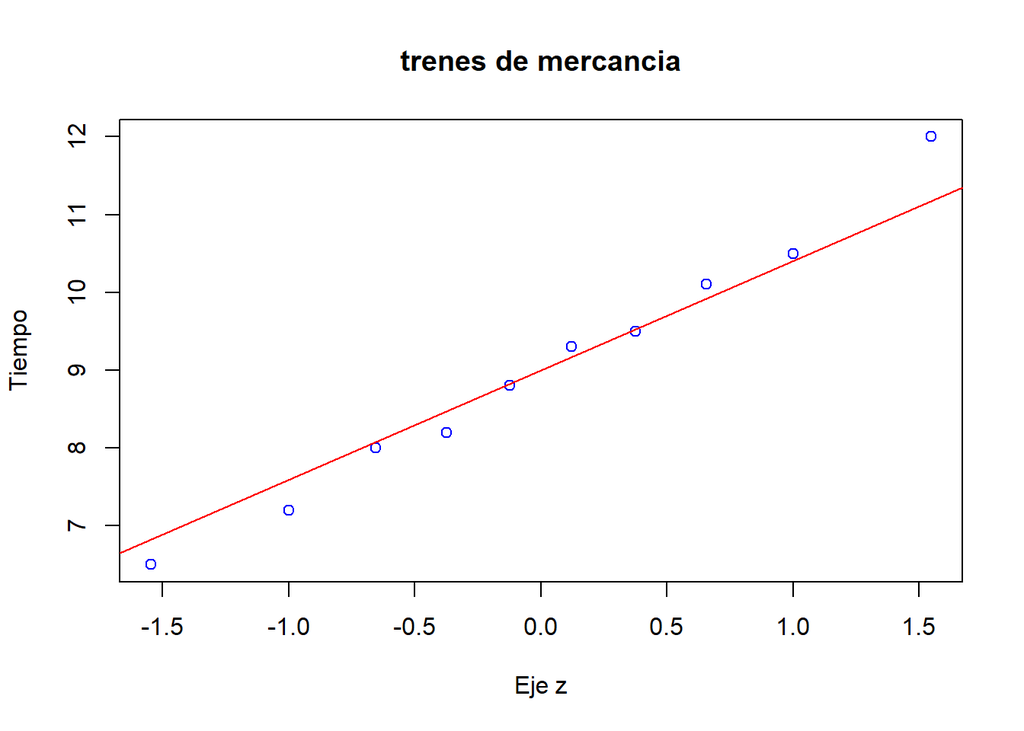

```r
#Se verifica normalidad de los datos.
qqnorm(datos1,col="blue",xlab="Eje z",ylab="Tiempo", main="trenes de mercancia"); qqline(datos1,col="red")
```

```r
t.test(datos1,mu=8,alternative="greater")
```

```
##
##  One Sample t-test
##
## data:  datos1
## t = 1.9571, df = 9, p-value = 0.04101
## alternative hypothesis: true mean is greater than 8
## 95 percent confidence interval:
##  8.063996      Inf
## sample estimates:
## mean of x
##      9.01
```

p-value = 0.04101>0.01=alpha

No se rechaza H0

Conclusion:Con un nivel de significancia del 1%, no existe suficiente evidencia estadística para concluir que los trenes de mercancías no bloquean los pasos a nivel durante más de 8 minutos.

**Inferencias Basadas en dos Muestras. Procedimientos de Prueba para la Diferencia de medias**

**CASO I: POBLACIONES NORMALES CON VARIANZAS CONOCIDAS o muestras grandes.**

Varias personas afirman que el ciclista 2 ganara la carrera, a un nivel de significancia del 5% comprobar las especulaciones de las personas asumiento una varianza igual para ambos ciclistas.

Ciclista1:(130,129,130,124,124,122,130,125,126,123,130,126,125,128,125,125,125,125,125,125,130,123,120,122,125,123,122,127,120,121,122)

Ciclista2:(128,130,125,125,127,123,130,125,124,123,130,125,125,129,125,125,125,124,125,125,130,122,121,121,125,125,122,128,121,125,122)

1. mu_1:tiempo promedio del ciclista 1 Mu_2:tiempo promedio del ciclista 2
2. mu_2< mu_1 es lo mismo que mu_1 > mu_2
3. H_0:mu_2>=mu_1 H_1:mu_2<mu_1 (mu_2-mu_1<0)

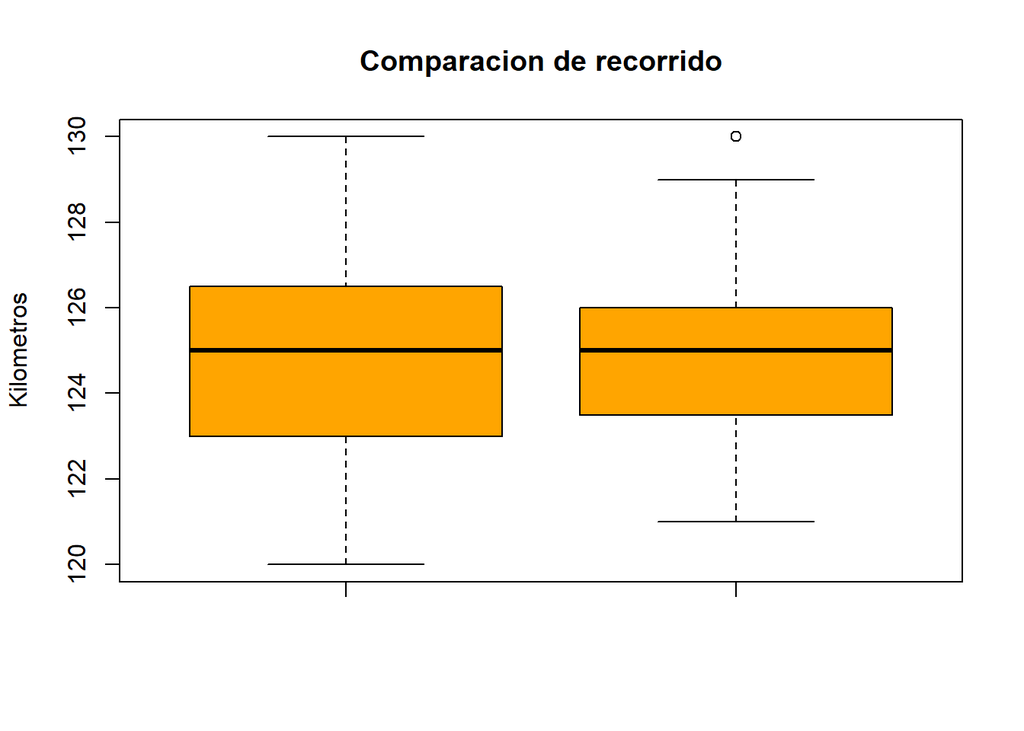

```r
ciclista_1<-c(130,129,130,124,124,122,130,125,126,123,130,126,125,128,125,125,125,125,125,125,130,123,120,122,125,123,122,127,120,121,122)
ciclista_2 <- c(128,130,125,125,127,123,130,125,124,123,130,125,125,129,125,125,125,124,125,125,130,122,121,121,125,125,122,128,122,121,125)

boxplot(ciclista_1,ciclista_2,main="Comparacion de recorrido",ylab="Kilometros",col="Orange")
```

Ahora que sabemos que las varianzas son desconocidas y que podemos asumir que son normales sus poblaciones con varianzas iguales realizaremos la prueba de hipotesis:

H_1:mu_2<mu_1 (mu_2-mu_1<0)

```r
if(!require("BSDA")){
install.packages("BSDA")
library("BSDA")
}
z.test(x=ciclista_2,y=ciclista_1,alternative="less",mu=0,sigma.x=sd(ciclista_2),sigma.y=sd(ciclista_1),conf.level=0.95)
```

```
##
##  Two-sample z-Test
##
## data:  ciclista_2 and ciclista_1
## z = 0.13277, p-value = 0.5528
## alternative hypothesis: true difference in means is less than 0
## 95 percent confidence interval:
##        NA 1.295659
## sample estimates:
## mean of x mean of y
##  125.1613  125.0645
```

p-values=0.5528>0.05=alpha no se rechaza la hipotesis nula Interpretación: Con un nivel de significancia del 5% no existe suficiente evidencia estadística para concluir que el ciclista 2 ganará la carrera.

**CASO II: POBLACIONES NORMALES CON VARIANZAS DESCONOCIDAS PERO IGUALES Y MUESTRAS PEQUEÑAS.**

Ejemplo: Un dueño de una fábrica tiene un pedido muy grande y para llevarlo a cabo necesita conocer cuál de las dos máquinas para realizar el proceso trabaja con mayor velocidad, el intuye que la maquina 2 es más efectiva y para ello hace una prueba, toman el tiempo de fabricación en minutos de 10 productos en cada máquina. Los resultados son:

maquina_1 <- c(14,13,15,14,17,16,15,16,13,17) maquina_2 <- c(16,15,14,17,12,17,15,16,15,14)

¿Es posible que la maquina 2 tenga un mejor tiempo de producción que la maquina 1 usando un nivel de significancia de 0.05?

1. mu_1:Tiempo medio de produccion de la maquina 1 mu_2:Tiempo medio de produccion de la maquina 2
2. m_2 < m_1
3. H_0:mu_2>=mu_1 H_1:mu_2<mu_1 (mu_2-mu_1<0)

```r
maquina_1 <- c(14,13,15,14,17,16,15,16,13,17)
maquina_2 <- c(16,15,14,17,12,17,15,16,15,14)
```

Ahora veremos si nuestras muestras son normales:

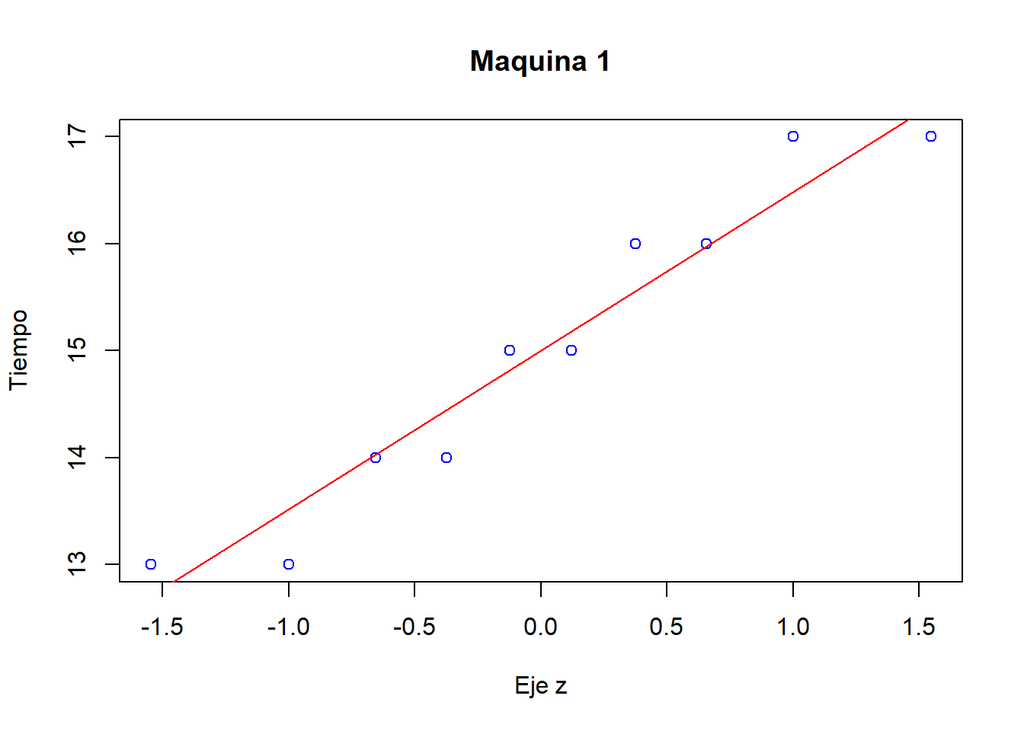

```r
qqnorm(maquina_1,col="blue",xlab="Eje z",ylab="Tiempo", main="Maquina 1"); qqline(maquina_1,col="red")
```

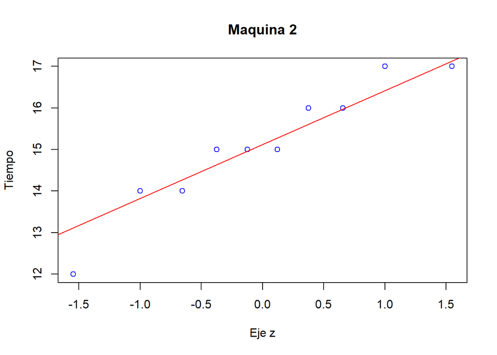

```r
qqnorm(maquina_2,col="blue",xlab="Eje z",ylab="Tiempo", main="Maquina 2"); qqline(maquina_2,col="red")
```

Una vez comprobado que son normales, usaremos nuestra prueba de hipótesis, donde nuestra hipótesis alternativa. H_1:mu_2<mu_1

```r
t.test(x=maquina_2,y=maquina_1,alternative="less",mu=0,var.equal=TRUE,conf.level=0.95)
```

```
##
##  Two Sample t-test
##
## data:  maquina_2 and maquina_1
## t = 0.14834, df = 18, p-value = 0.5581
## alternative hypothesis: true difference in means is less than 0
## 95 percent confidence interval:
##      -Inf 1.268976
## sample estimates:
## mean of x mean of y
##      15.1      15.0
```

p=value=0.55>0.05=alpha no se rechaza H_0 Conclusión:Con un nivel de significancia del 5% no existe suficiente evidencia estadistica para concluir que la maquina 2 tiene un mejor tiempo de producción que la maquina 1.

**Prueba de hipotesis para proporciones* Considerando nuevamente el conjunto de datos que se ha presentado en el Supuesto práctico1, relativo al número de flexiones y el sexo de los alumnos.

Contrastar a un nivel de confianza del 95%, si la proporción de alumnos varones es mayor o igual que 0.5 frente a que dicha proporción es menor. El fichero es Flexiones.txt.

```r
if(!require("readxl")){
install.packages("readxl")
library("readxl")
}
datos<- read_excel("Flexiones.xlsx")
table(datos$Sexo)
```

```
##
##  H  M
## 43 32
```

P:PROPORCIÓN DE ALUMNOS QUE SON HOMBRES

H_0:P>=0.5

H_1:P<0.5

```r
datos$Sexo
```

```
##  [1] "H" "H" "M" "M" "H" "H" "H" "M" "M" "M" "M" "M" "H" "M" "M" "H" "H" "H" "H"
## [20] "H" "H" "M" "M" "M" "M" "M" "M" "H" "H" "M" "H" "M" "M" "H" "M" "H" "M" "H"
## [39] "H" "M" "M" "H" "M" "H" "M" "M" "H" "M" "M" "H" "H" "H" "M" "M" "H" "H" "H"
## [58] "M" "H" "M" "H" "H" "H" "H" "H" "H" "H" "H" "H" "H" "H" "H" "H" "M" "H"
```

```r
x<-length(which(datos$Sexo=="H"))
x
```

```
## [1] 43
```

```r
n<-length(datos$Sexo)
prop.test(x,n,p=0.5,alternative="less", conf.level = 0.95)
```

```
##
##  1-sample proportions test with continuity correction
##
## data:  x out of n, null probability 0.5
## X-squared = 1.3333, df = 1, p-value = 0.8759
## alternative hypothesis: true p is less than 0.5
## 95 percent confidence interval:
##  0.0000000 0.6693525
## sample estimates:
##         p
## 0.5733333
```

P: proporcion de llamadas de emergencias de vida o muerte recibidas en el servicio de ambulancia

P>=0.4

H_0: P >= 0.4 H_1: P < 0.4

Zc=-1.83333

z_alpha=-2.3263

Para rechazar se debe cumplir que zc< z_alpha y esto no ocurre conclusion: No se rechaza la HO

Inter: Con un nivel de significancia del 1% no existe suficiente evidencia estadistica para rechazar que la proporcion de llamadas de vida o muerte recibidas por el servicio de ambulancias es al menos el 40%.

Con un nivel de significancia del 1% no existe suficiete evidencia estadistica para concluir que la proporcion de llamadas de vida o muerte recibidas por el servicio de ambulancias es menor al 40%.

```r
zc=(49/150 - 0.4)/(sqrt((0.4*0.6)/150))
zc
```

```
## [1] -1.833333
```

```r
qnorm(0.01)
```

```
## [1] -2.326348
```